# WindACR1

## 5. ARMA Model Diagnostics and Predictions

Prior to carrying out (single-step and multiple step) predictions, we need to test the accuracy of the given models. For that we use the following series of diagnostic tests: - Zero Autocorrelation - Normality of Residues - Conditional Heteroskedasticity

### 5.1. Zero Autocorrelation

The Autocorrelation function (ACF) shows a reasonably clear image of the dependency of individual random variables with respect to time lag. This means that if the ACF has non-zero values for some lags greater than zero, then it is likely that the residues after removing the ARMA regression’s fitted values still contain some systematic or ARMA component. To find out we test for a null hypothesis: $ACF(k) = 0$ for all $k > 0$, against an alternative $ACF(k) \neq 0$ for some $k > 0$.

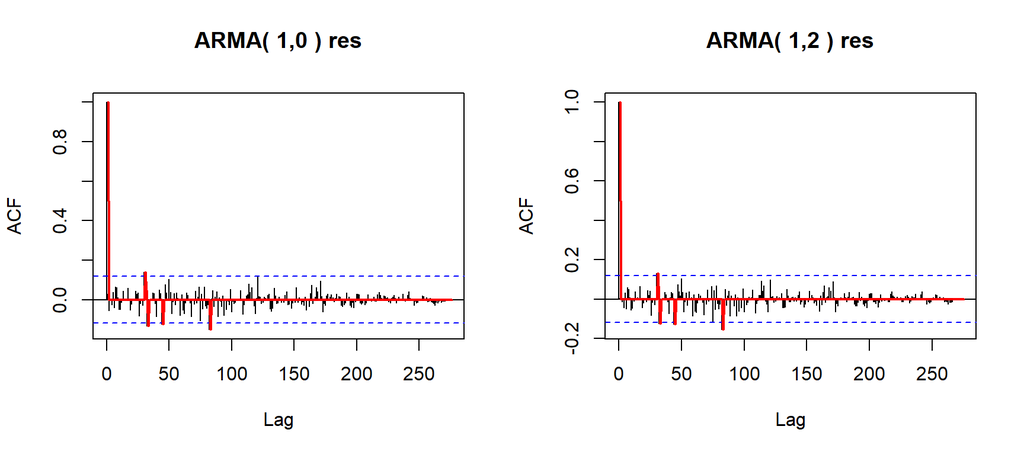

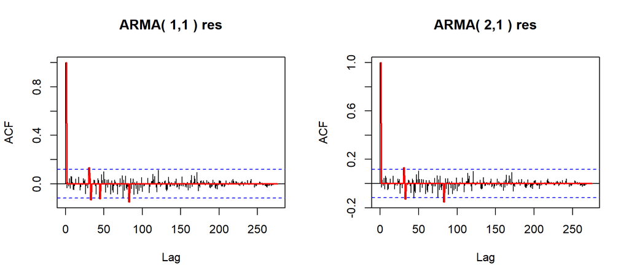

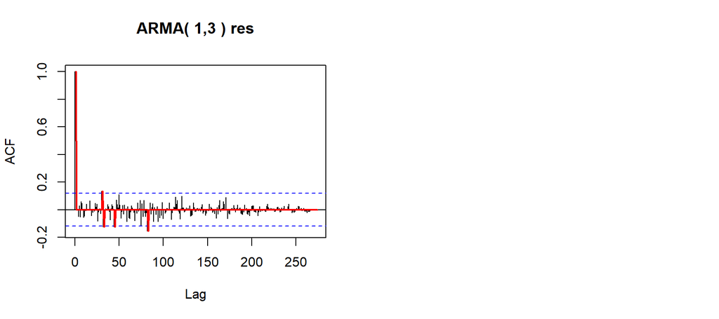

```
## [[1]]
##    zero.val      k_31       k_33       k_45       k_83
## 1 0.1201684 0.1391869 -0.1321801 -0.1246233 -0.1524518
##
## [[2]]
##    zero.val      k_31       k_33       k_45       k_83
## 1 0.1201684 0.1322945 -0.1241467 -0.1258402 -0.1552119
##
## [[3]]
##    zero.val      k_31       k_33       k_45       k_83
## 1 0.1201684 0.1354624 -0.1317632 -0.1235071 -0.1513151
##
## [[4]]
##    zero.val      k_31       k_33      k_83
## 1 0.1201684 0.1321383 -0.1284811 -0.154154
##
## [[5]]
##    zero.val      k_31       k_33       k_45       k_83
## 1 0.1201684 0.1338509 -0.1260332 -0.1250987 -0.1558347
```

we see the exact lags for which the ACF exceeds the zero-value.

### 5.2. Normality of Residues

If a given ARMA model describes the time series well enough, the residues should behave as if they were generated by a stochastic process with values at individual times $t$ being the realizations of independent identically distributed random variables. For sufficiently large number of time steps, the residues are assumed to be the results of a normally distributed random variable. To test that, we use the, so called, Jarque-Bera test:

[output not shown]

[output not shown]

[output not shown]

[output not shown]

[output not shown]

### 5.3. Conditional Heteroskedasticity

The term “heteroskedasticity” of a time series describes the tendency of its variance to change with time. A time series whose variance (up to a given time) remains the same are called “homoskedastic”. The following Breusch-Pagan test assesses the homoskedasticity of a given model:

[output not shown]

[output not shown]

[output not shown]

[output not shown]

[output not shown]

### 5.4. Forecasting and Single-Step Predictions

Now we make use of the evaluation part of the time series which we have separated from the original series earlier in section 4. Since the `dynlm` model we used earlier does not support `predict()` function from the `forecast` library we use equivalent $ARIMA(p,0,q)$ models instead of $ARMA(p,q)$, which are returned by an inbuilt function `arima()`, the result of which is an object that can be processed by the `predict()` call.

```
## [1] 70
```

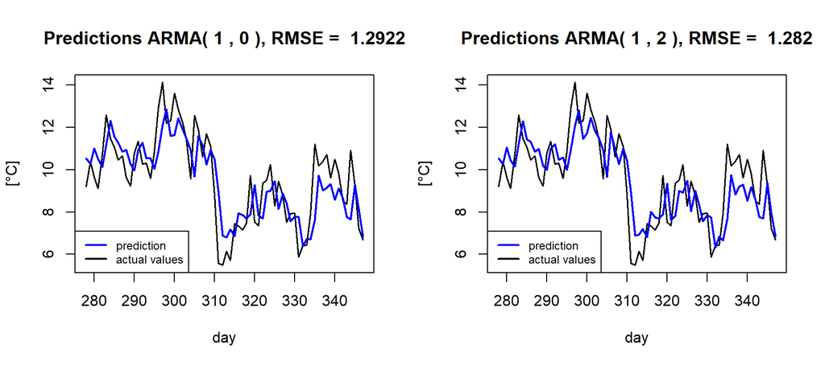

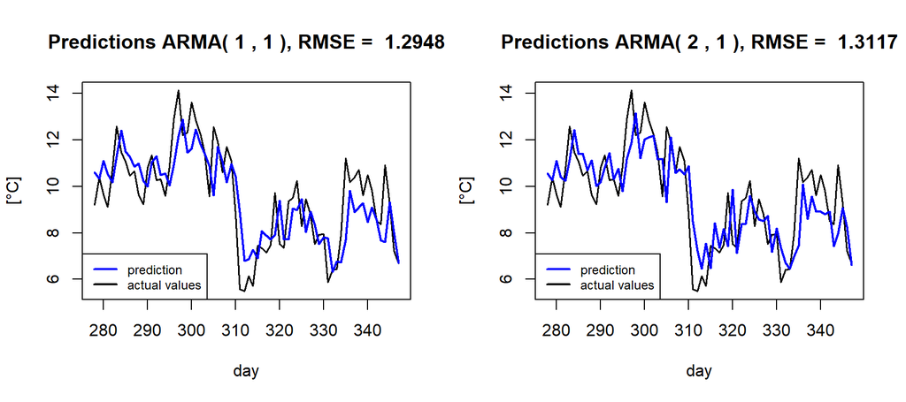

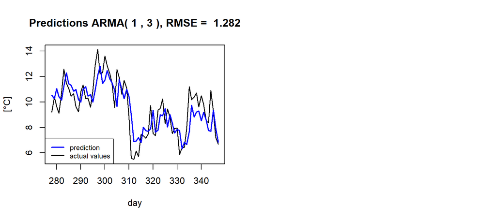

We have also computed Root Mean Square Errors for each model.

### 5.5. Comparison of Predictive Abilities Using the Diebold-Mariano Test

Taking two different ARMA models, the null hypothesis of the test states that both models have equal predictive abilities. We will be comparing 5 different models against each other, which will essentially amount to testing the predictive abilities of 10 distinct pairs of models. Practically, the test results can be expressed in a $5 \times 5$ “DieboldMarianoMatrix” with values $0$ (if model $i$ has the same predictive abilities as model $j$), $1$ (if model `i` has better predictive abilities than model $j$), and $-1$ (the other way around):

```
##      [,1] [,2] [,3] [,4] [,5]
## [1,]    0    0    0    0    0
## [2,]    0    0    0    0    0
## [3,]    0    0    0    0    0
## [4,]    0    0    0    0    0
## [5,]    0    0    0    0    0
```

As the results of the Diebold-Mariano test suggest, no model has significantly better predictive abilities on a 5% significance level. A quantitative characteristic of predictive ability is the Root Mean Square Error (RMSE). Here we can see how the predictions match the observed values from the evaluation part of the time series:

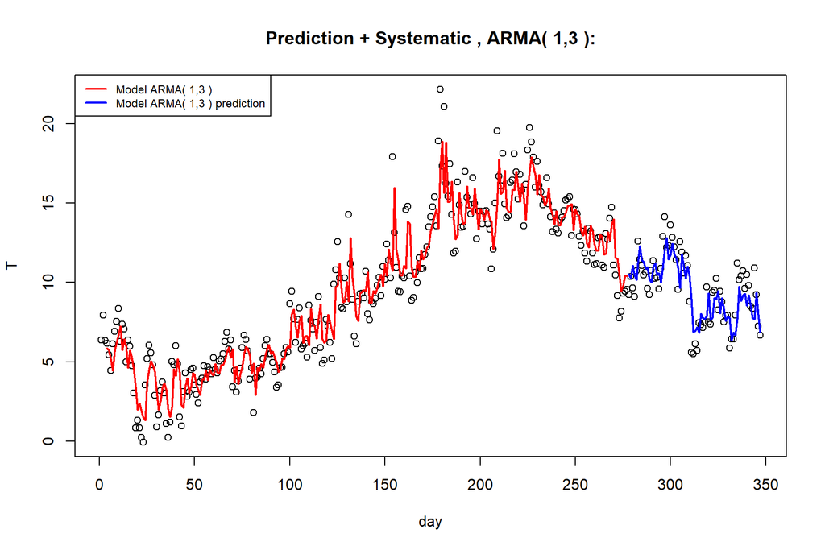

### 5.6 Multiple-Step Predictions

Predicting one step ahead of data can be done naiively by fitting and ARMA model on the entire time series (both test and evaluation segments). Once we reach the end of the dataset, however, we must predict with an increasing amount of uncertainty. This can be done by recursive accumulation of the past values (based on AR an MA parameters). A `predict()` method for an `arima` (or `Arima`) fit can perform this task for an arbitrary forecast horizon. The `forecast` package contains a method (with the same name) which also includes confidence levels (80% and 95% as default) enclosing the predicted values which tend towards a stable mean. The confidence intervals can grow with increasing steps, especially for models with higher MA degrees.

In this section we compare the multiple-step predictions (with the length of the evaluation part) for the top 5 ARMA models:

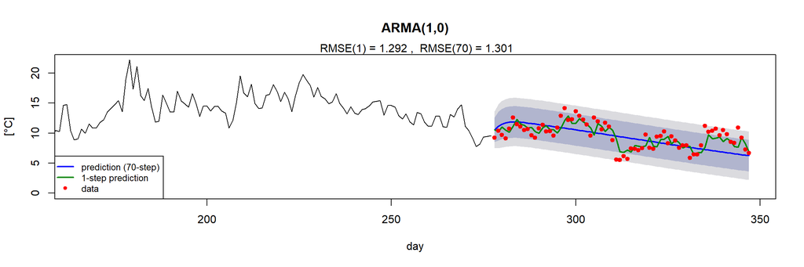

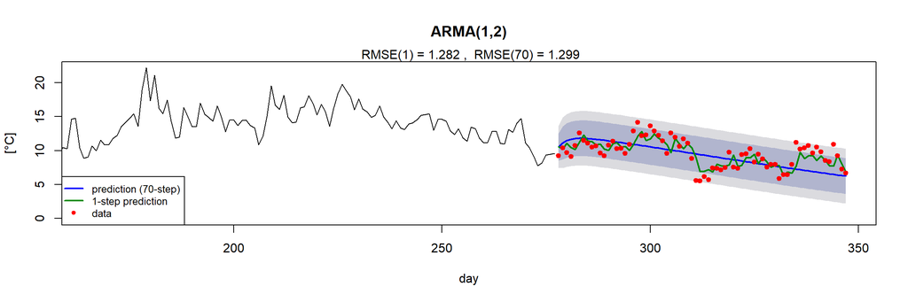

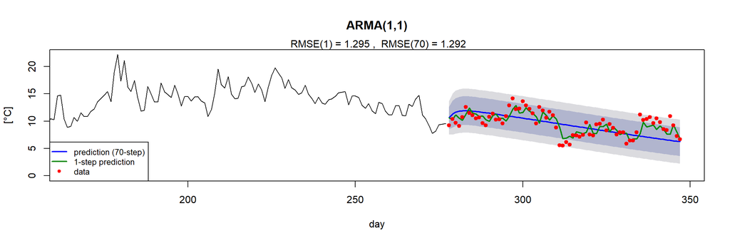

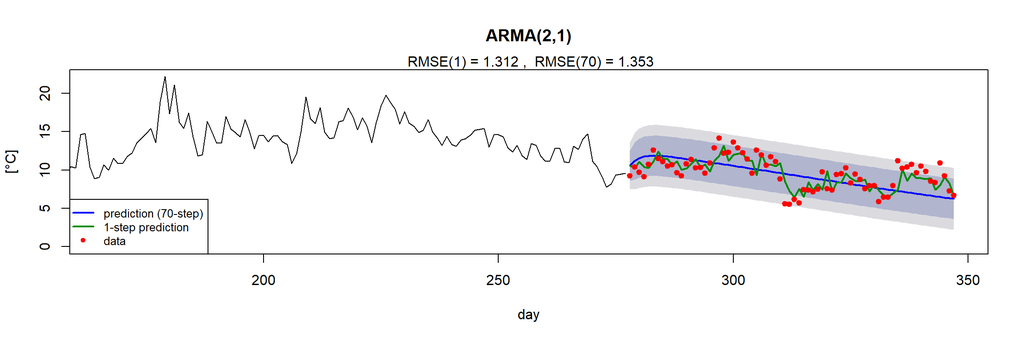

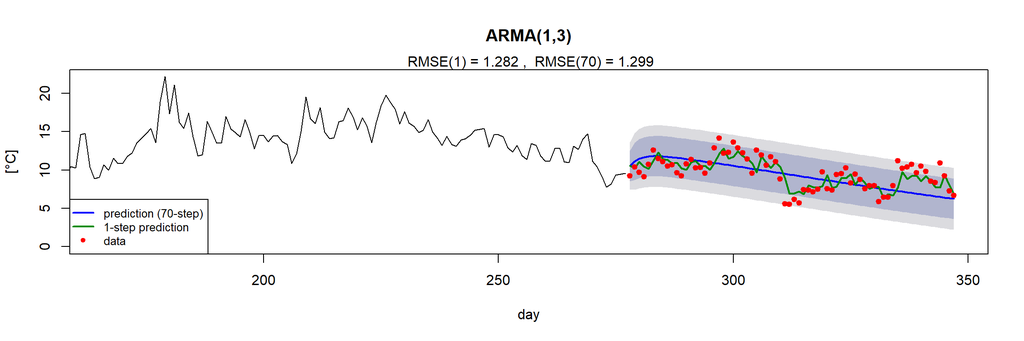

Now even though we have no validation for our models for $t > n$ where $n$ is the length of the time series, we can use our models to make a forecast for another year (more precisely, year 2016):

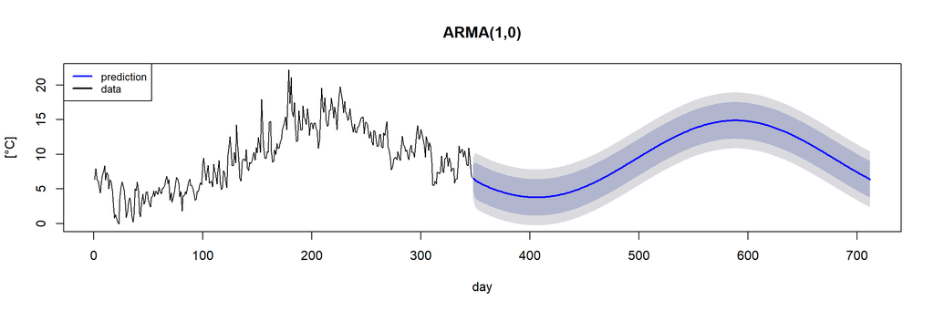

And unless we take global warming (a possible trend), for example, into account we can assume this prediction to be valid. Since our dataset is only a year long we are unable to make any assumptions about possible long-term changes in temperature.

## 6. Non-Stationary Models

ARMA type models can be used when we safely assume stationarity of the time series. Namely, when the series has a constant variance its mean values and covariances only depend on the lag, not on time. Although ARMA models seem to sufficiently describe the given time series, we may want to try out the so called Integrated processes.

### 6.1. Diagnostic Tests

First we will test whether the original time series after extracting the seasonal component has the properties of a non-stationary process. The most common approach involves testing for unit-roots of the process’ characteristic polynomial. We begin by testing the residuals after filtering seasonal components via the Dickey-Fuller (DF) test.

#### 6.1.1 Dickey-Fuller Test (DF)

The null hypothesis of the DF test states: $x_t = x_{t-1} + e_t$, that is, the time series is a realization of a random walk process. It is carried out by setting $\Delta x_t = x_t - x_{t-1} = \rho \ x_{t-1} + e_t$ where $e_t$ is an i.i.d process. It suffices to show that the $\rho$ parameter of such regression equals zero. In general, the regression may assume $\Delta x_t = \mu + \delta \ t + \rho \ x_{t-1} + e_t$ with additional parameters $\mu$ (mean value) and $\delta$ (deterministic drift).

```
##                  Estimate  Std. Error    t value     Pr(>|t|)
## (Intercept)  0.0564037907 0.191348066  0.2947706 7.683931e-01
## xt1         -0.3556288534 0.046494747 -7.6487964 3.487374e-13
## tt          -0.0006086961 0.001198388 -0.5079291 6.119132e-01
```

And after the regression of the difference time series we proceed to compute the $DF$-statistic from the `rho` parameter:

```
## [1] -7.648796
```

The value has to be compared with the critical values for the `DF`-statistic, whose distribution is estimated via simulations for particular sample sizes:

```r
critVals <- -c(3.60, 3.50, 3.45, 3.43, 3.42, 3.41) # for alpha = 0.05
sampleSizes <- c(25, 50, 100, 250, 500, 100000) # sample size
```

```
## [1] -3.42896
```

```
##  DF =  -7.6488  <  -3.42896 , rho =  -0.3556  ::: Null Hypothesis rejected. Stochastic trend insignificant.
```

The presence of a stochastic trend for process $\Delta x_t = \mu + \delta \ t + \rho \ x_{t-1} + e_t$ is rejected on a 5% significance level. This means that the residual time series after extracting the seasonal deterministic should not be modelled as an integrated process. We can compare the results with the inbuilt `adf.test` function from `tseries` package:

```
##
##  Augmented Dickey-Fuller Test
##
## data:  x
## Dickey-Fuller = -7.6488, Lag order = 0, p-value = 0.01
## alternative hypothesis: stationary
```

#### 6.1.2 Augmented Dickey-Fuller Test (ADF)

The same procedure can be generalized for lags $k > 0$ as well. For that we can just use the method from `tseries` package:

```
##          DF
## 1 -7.299007
## 2 -6.320025
## 3 -5.839016
## 4 -5.108259
## 5 -4.834637
```

#### 6.1.3 Phillips-Perron Test

Similarily to the DF test, the PP-test is, again, a unit-root test which relies on regressing $\Delta X \sim \mu + \delta \ t + \rho X_{t - 1}$. While the ADF test adresses the issue of the time series being potentially generated by a process of higher orders by using lags $k = 1, 2, ...$ and expanding the regression equation, PP-test makes a non-parametric correction to the t-statistic.

```
##
##  Phillips-Perron Unit Root Test
##
## data:  x
## Dickey-Fuller Z(alpha) = -95.934, Truncation lag parameter = 5,
## p-value = 0.01
## alternative hypothesis: stationary
```

This makes the PP-test robust with respect to unspecified autocorrelation and heteroskedasticity.

#### 6.1.4 KPSS Test

Published by Kwiatkovski, Philips, Schmidt, and Shin (1992), another test approaches the stationarity-vs-non-stationarity issue from an opposite point of view. Using KPSS we can test for stationarity hypothesis (about a deterministic trend). Contrary to the previously used tests, the presence of a unit root is the alternative. It can be used in cases when unit roots hypothesis cannot be rejected and the time series coult be non-stationary (or we have a sample of insufficient length). The test relies on testing for zero variance of an i.i.d process present in the stochastic trend part in $x_t \sim ST_t + \epsilon_t$, or alternatively with deterministic trend: $x_t \sim ST_t + \delta \ t + \epsilon_t$.

```
##
## Call:
## lm(formula = x ~ 1)
##
## Residuals:
##     Min      1Q  Median      3Q     Max
## -5.0958 -1.3331 -0.1792  1.2668  8.8419
##
## Coefficients:
##             Estimate Std. Error t value Pr(>|t|)
## (Intercept) -0.04412    0.12386  -0.356    0.722
##
## Residual standard error: 2.061 on 276 degrees of freedom
```

```
##      KPSS      pval
## 0.1616852 0.1000000
```

As it appears, the stationarity null hypothesis is accepted. With `pvalue > 0.1`. The same result can be obtained using the `kpss.test` function from the `tseries` package:

```
##
##  KPSS Test for Level Stationarity
##
## data:  x
## KPSS Level = 0.16169, Truncation lag parameter = 3, p-value = 0.1
```

```
##
##  KPSS Test for Trend Stationarity
##
## data:  x
## KPSS Trend = 0.17121, Truncation lag parameter = 3, p-value =
## 0.02899
```

```
## [1] 0.02899005
```

By regressing the given trend

```
##
## Call:
## lm(formula = x ~ t)
##
## Residuals:
##     Min      1Q  Median      3Q     Max
## -4.8830 -1.2612 -0.2181  1.2207  8.9055
##
## Coefficients:
##              Estimate Std. Error t value Pr(>|t|)
## (Intercept)  0.176611   0.248370   0.711    0.478
## t           -0.001588   0.001549  -1.025    0.306
##
## Residual standard error: 2.061 on 275 degrees of freedom
## Multiple R-squared:  0.003808,   Adjusted R-squared:  0.0001856
## F-statistic: 1.051 on 1 and 275 DF,  p-value: 0.3061
```

```
##       KPSS       pval
## 0.17121194 0.02899005
```

we reject the stationarity about a trend null hypothesis. The test can also be carried out for larger values of truncation lag parameter:

```
##
##  KPSS Test for Level Stationarity
##
## data:  x
## KPSS Level = 0.10567, Truncation lag parameter = 11, p-value = 0.1
```

```
##
##  KPSS Test for Trend Stationarity
##
## data:  x
## KPSS Trend = 0.11147, Truncation lag parameter = 11, p-value = 0.1
```

### 6.2 Identifying Models of Integrated Processes

The diagnostic tests carried out in the previous section suggest that the residuals `temp_test$Tres` are generated by a stationary stochastic process. The `auto.arima` method from the `forecast` package searches through a multitude of combinations of parameters, just like we did in section 4 when searching for the best ARMA model:

```r
auto.arima(x, ic = "bic")
```

```
## Series: x
## ARIMA(1,0,0) with zero mean
##
## Coefficients:
##          ar1
##       0.6446
## s.e.  0.0460
##
## sigma^2 estimated as 2.489:  log likelihood=-519.11
## AIC=1042.22   AICc=1042.27   BIC=1049.47
```

The result corresponds to the best ARMA model, and thus confirms the validity of our approach in section 4.

The original time series without the deterministic annual wave caused by the Earth’s tilt during orbit around the Sun could still be modeled as a non-stationary process (about some deterministic wave). If we apply the same `auto.arima` method on the original time series without deterministic seasonal component:

```
## Series: x
## ARIMA(2,1,1)
##
## Coefficients:
##          ar1      ar2      ma1
##       0.5917  -0.0918  -0.8495
## s.e.  0.0778   0.0660   0.0526
##
## sigma^2 estimated as 2.667:  log likelihood=-525.72
## AIC=1059.44   AICc=1059.59   BIC=1073.93
```

This means that the original temperature data can be modeled as an ARIMA process with $d = 1$.

#### 6.2.1 ARIMA

```
##   p d q       RSS      AIC      BIC
## 1 0 0 0 23.645563 1666.292 1673.540
## 2 0 1 0  3.020192 1090.323 1093.943
## 3 0 2 0  6.892640 1313.291 1316.908
## 4 0 0 1  9.227762 1408.734 1419.606
## 5 0 1 1  2.919516 1083.031 1090.271
## 6 0 2 1  3.031040 1094.986 1102.219
```

And like we did in section 4, after getting a large set of models of varying quality, we sort the resulting list according to their $BIC$’s:

```
##    p d q      RSS      AIC      BIC
## 23 1 1 1 2.656345 1059.357 1070.218
## 41 2 1 1 2.637686 1059.444 1073.925
## 26 1 1 2 2.637728 1059.446 1073.927
## 44 2 1 2 2.563032 1055.872 1073.974
## 8  0 1 2 2.697468 1063.540 1074.401
## 11 0 1 3 2.654986 1061.227 1075.709
```

#### 6.2.2 ARFIMA

So far we have restricted ourselves to searching through parameter spaces of smaller lag order values (for the sake of reducing computation time). There is however, an alternative for modelling ARIMA-type processes with long memory. This may assess the fact that the nonzero values of the data’s ACF still appear after 30 steps.

```
##   p         d q      RSS      BIC
## 1 0 0.4982451 0 1.661838 1078.894
## 2 0 0.4915776 1 1.623401 1069.949
## 3 0 0.4930615 2 1.623663 1075.861
## 4 0 0.4925084 3 1.625521 1082.029
## 5 0 0.4934222 4 1.625062 1087.641
## 6 0 0.4925344 5 1.627004 1093.786
```

```
##    p         d q      RSS      BIC
## 2  0 0.4915776 1 1.623401 1069.949
## 7  1 0.4915842 0 1.628347 1071.625
## 8  1 0.4922014 1 1.622568 1075.368
## 3  0 0.4930615 2 1.623663 1075.861
## 10 2 0.4935720 0 1.624515 1076.230
## 1  0 0.4982451 0 1.661838 1078.894
```

### 6.3 Predictive Properties of the Chosen Models

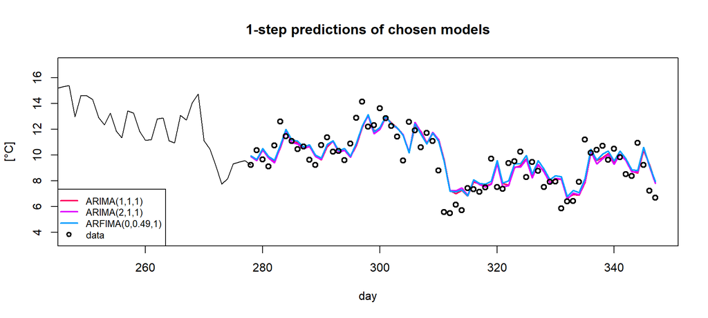

We also consider the predictive properties of the chosen set of models. We will be comparing the top 6 models from each type.

#### 6.3.1 ARIMA

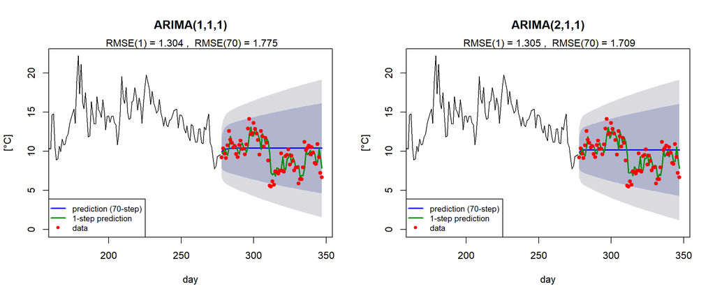

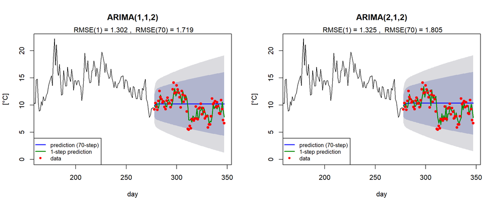

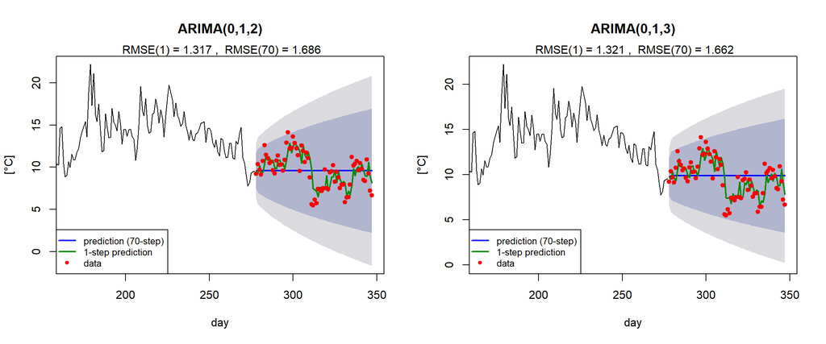

#### 6.3.2 ARFIMA

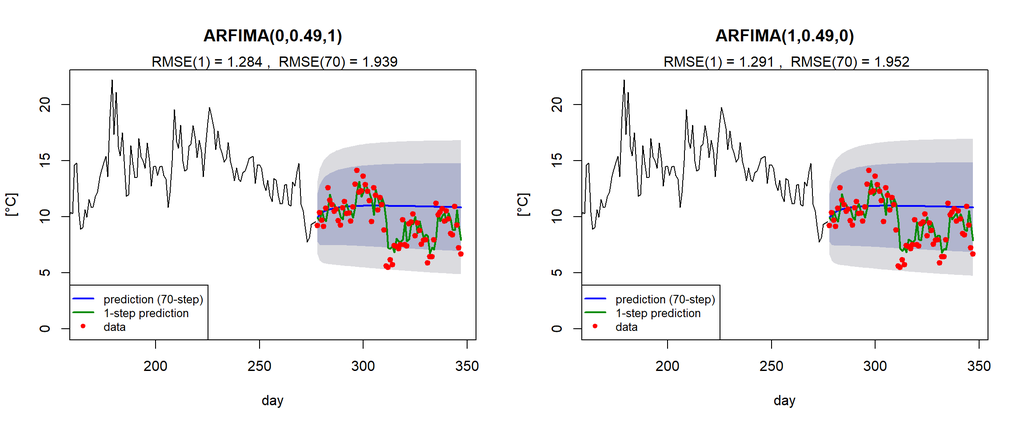

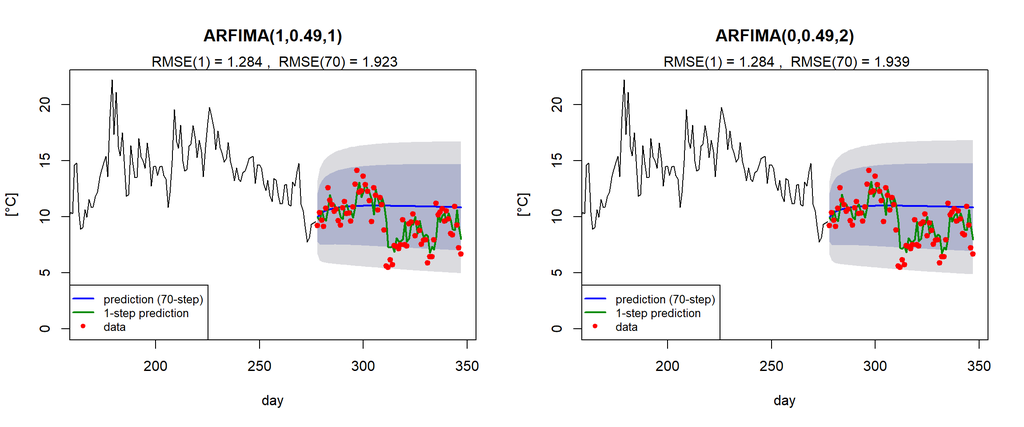

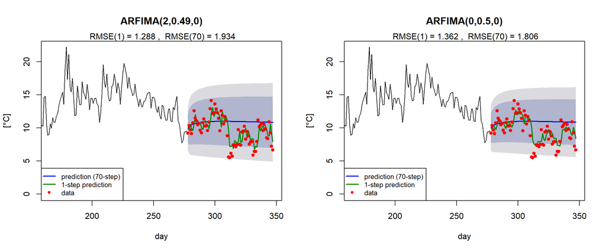

#### 6.3.4 Comparison of Predictive Properties

```
##               model RMSE(1)         RMSE(70)      BIC
## 17        ARMA(1,3) 1.28197                - 1058.852
## 14        ARMA(1,2) 1.28199                - 1056.256
## 10 ARFIMA(0,0.49,2) 1.28375          1.93873 1075.861
## 9  ARFIMA(1,0.49,1) 1.28393          1.92318 1075.368
## 7  ARFIMA(0,0.49,1) 1.28419          1.93877 1069.949
## 11 ARFIMA(2,0.49,0) 1.28776          1.93367  1076.23
## 8  ARFIMA(1,0.49,0) 1.29106          1.95195 1071.625
## 13        ARMA(1,0) 1.29222                - 1051.252
## 15        ARMA(1,1) 1.29477                - 1056.484
## 3      ARIMA(1,1,2) 1.30158 1.71851566505831 1073.927
## 1      ARIMA(1,1,1) 1.30404  1.7748070000343 1070.218
## 2      ARIMA(2,1,1) 1.30542 1.70898861814545 1073.925
## 16        ARMA(2,1) 1.31172                - 1057.184
## 5      ARIMA(0,1,2) 1.31749 1.68636006146712 1074.401
## 6      ARIMA(0,1,3) 1.32113 1.66194761023698 1075.709
## 4      ARIMA(2,1,2) 1.32477 1.80451796799625 1073.974
## 12  ARFIMA(0,0.5,0) 1.36153          1.80551 1078.894
```

And we can apply the DM test on first 6 models:

```
##      [,1] [,2] [,3] [,4] [,5] [,6]
## [1,]    0    0    0    0    0    0
## [2,]    0    0    0    0    0    0
## [3,]    0    0    0    0    0    0
## [4,]    0    0    0    0    0    0
## [5,]    0    0    0    0    0    0
## [6,]    0    0    0    0    0    0
```

```
##       [,1]  [,2]  [,3]  [,4]  [,5]  [,6]
## [1,] 1.000 0.875 0.979 0.977 0.974 0.932
## [2,] 0.875 1.000 0.979 0.977 0.974 0.932
## [3,] 0.979 0.979 1.000 0.964 0.521 0.082
## [4,] 0.977 0.977 0.964 1.000 0.955 0.465
## [5,] 0.974 0.974 0.521 0.955 1.000 0.080
## [6,] 0.932 0.932 0.082 0.465 0.080 1.000
```

```
##          model  better than
## 1 ARIMA(2,1,1) ARIMA(1,1,2)
```

### 6.4 Conclusions

As the matter of fact, different types of models of integrated processes capture different properties of the time series. We decided not to use SARIMA models since the data does not contain at least two seasons, and also we refrained from using (G)ARCH type models since the residuals of `model.sCos` are conditionally homoskedastic and there is no regression to BP-test against in the case of the original time series temperature data.

While ARIMA and ARFIMA models seem to account for much of the non-stationarity in the original time series, they have larger $BIC$ than their ARMA counterparts on the systematic residuals:

```
##               model RMSE(1)      BIC
## 13        ARMA(1,0) 1.29222 1051.252
## 14        ARMA(1,2) 1.28199 1056.256
## 15        ARMA(1,1) 1.29477 1056.484
## 16        ARMA(2,1) 1.31172 1057.184
## 17        ARMA(1,3) 1.28197 1058.852
## 7  ARFIMA(0,0.49,1) 1.28419 1069.949
## 1      ARIMA(1,1,1) 1.30404 1070.218
## 8  ARFIMA(1,0.49,0) 1.29106 1071.625
## 2      ARIMA(2,1,1) 1.30542 1073.925
## 3      ARIMA(1,1,2) 1.30158 1073.927
## 4      ARIMA(2,1,2) 1.32477 1073.974
## 5      ARIMA(0,1,2) 1.31749 1074.401
## 9  ARFIMA(1,0.49,1) 1.28393 1075.368
## 6      ARIMA(0,1,3) 1.32113 1075.709
## 10 ARFIMA(0,0.49,2) 1.28375 1075.861
## 11 ARFIMA(2,0.49,0) 1.28776  1076.23
## 12  ARFIMA(0,0.5,0) 1.36153 1078.894
```

However, it should be noted that the value of $BIC$ in the context of ARMA type models was evaluated on the residuals of a seasonal systematic fit without taking the systematic coefficients into account as parameters, whereas $BIC$’s of ARIMA and ARFIMA were fitted on the original data. Nevertheless the validity of the integrated models remains rather dubious, since we know that average daily temperature will change in more-or-less identical annual cycles, and these models were only used on original data as an exercise.

Thus quantitatively, ARMA models on residuals seem to outcompete the remaining categories of integrated processes on original data.

## 7. Exponential Smoothing Methods

Exponential smoothing techniques were among the first to appear (in 1950’s), and were, thanks to being relatively fast, used in various predictions and smoothings of time series. Whereas in MA-type models the finite moving averages contribute to each point using regression extimation of their coefficients, the ES technique uses an exponential window, i.e.: a weighed moving average of all values which decreases exponentially into the past.

### 7.1 Choice of a Smoothing Technique for our Data

Each time series could potentially have three properties which can be smoothed, namely:

1.) level (mean value)  
2.) trend (slope)  
3.) seasonality (containing weighed averages of each $L$ steps into the past)

The approach to each property can either be additive ($A$) or multiplicative ($M$). We will work with the residuals `temp_test$Tres` with extracted annual period, hence we will not model any seasonality, or trend. We are left with additive and multiplicative models of the exponential smoothing of mean values. The additive smoothing models are governed by the following set of recurrence equations:

$x_t = a_t + \epsilon_t$ (observation eqn’)

$a_t = a_{t-1} + \alpha \epsilon_t$ (state space eqn’), $\alpha \in [0, 1]$

for an additive error, and

$x_t = a_{t-1} (1 + \epsilon_t)$ (observation)

$a_t = a_{t-1} (1 + \alpha \epsilon_t)$ (state), $\alpha \in [0, 1]$

for a multiplicative error. In both cases the error can be expressed as $\epsilon_t = x_t - a_{t - 1} = x_t - \hat{x}_{t|t-1}$. Where $\hat{x}_{t|t-1}$ are prediction estimates from the previous step. The core idea behind simple exponential smoothing with additive error smoothing can be described using the following algorithm:

The errors $\epsilon_t^{Add} = x - \hat{x}_{t|t-1}$ and $\epsilon_t^{Mult} = \frac{x - \hat{x}_{t|t-1}}{\hat{x}_{t|t-1}}$ can be reduced to the formula we used for pointwise smoothing: $\hat{x}_{t|t} = \alpha x_t + (1 - \alpha) \hat{x}_{t|t-1}$. The model $AIC$ and $BIC$ are computed with respect to the total of two estimated parameters: initial state and $\alpha$.

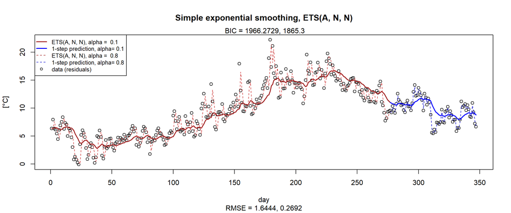

We observe that with $\alpha \rightarrow 1^-$ the simple ETS model fits the data more precisely, but at the same time does not account for the error terms properly. Models with different smoothing parameters need to be examined according to some information criterion.

```
##   alpha  sigma^2      AIC      BIC
## 1 0.001 30.84835 2511.709 2518.957
## 2 0.002 28.44725 2489.263 2496.511
## 3 0.003 26.25591 2467.059 2474.307
## 4 0.004 24.27514 2445.331 2452.579
## 5 0.005 22.49620 2424.250 2431.498
## 6 0.006 20.90508 2403.931 2411.179
```

Now that we searched through 1000 simple ES models with distinct smoothing parameters $\alpha$ we choose the first 2 with the lowest $BIC$:

```
##     alpha  sigma^2      AIC      BIC
## 747 0.747 2.909290 1857.664 1864.912
## 748 0.748 2.909290 1857.664 1864.912
## 746 0.746 2.909292 1857.664 1864.912
## 749 0.749 2.909293 1857.664 1864.912
## 745 0.745 2.909298 1857.664 1864.912
## 750 0.750 2.909299 1857.665 1864.913
```

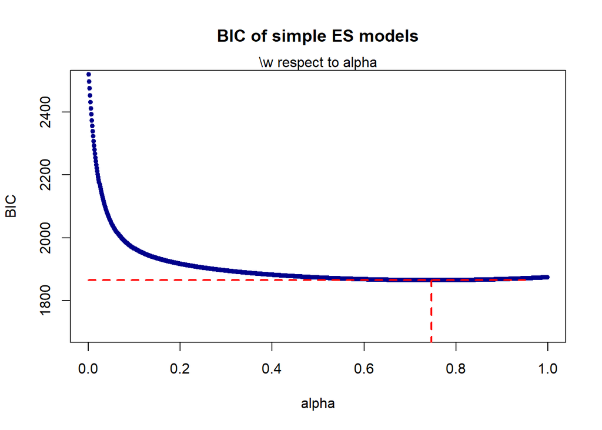

### 7.2 Automatic ETS Model Search Method

Using an `ets` method from the `forecast` package we obtain the same best model:

```
## ETS(A,N,N)
##
## Call:
##  ets(y = x)
##
##   Smoothing parameters:
##     alpha = 0.7467
##
##   Initial states:
##     l = 6.6519
##
##   sigma:  1.7056
##
##      AIC     AICc      BIC
## 1859.633 1859.721 1870.505
```

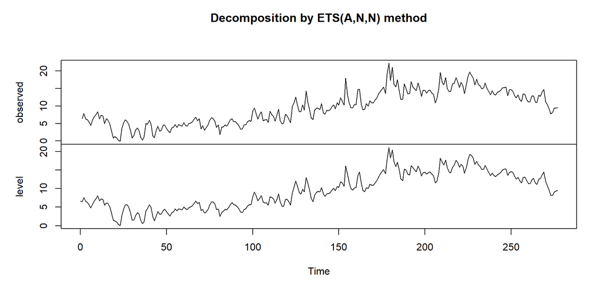

As we notice, the value of smoothing parameter $\alpha$ closer to 1 has a much more subtle smoothing effect than that of models with smaller $\alpha$s. The `ets` method examines a much larger search space than the one we chose for demonstration. In fact, it tests for multiple available combinations of ETS models with additional parameters: $\beta$ (trend), $\gamma$ (season), and $\phi$ (trend damping).

The method also allows multiple-step predictions which we can then display with seasonal fit included:

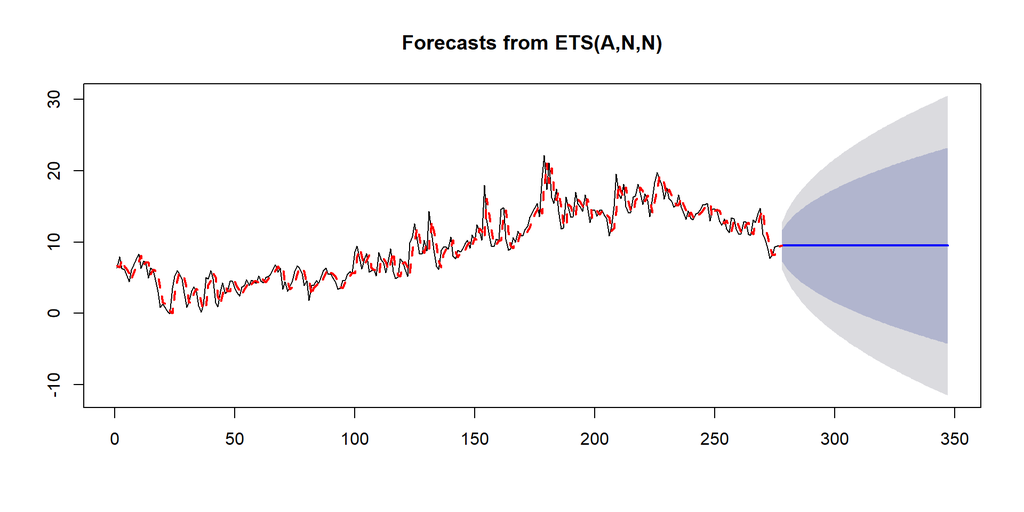

### 7.3 Single and Multi-Step Prediction Estimates

Each state variable is a 1-step prediction of the previous values. This makes 1-step predictions relatively straight-forward, as observed on eval parts of chosen models in the beginning of section 7.1. To predict $h > 1$ steps ahead we make use of the state space equations to accumulate the levels as well as additional ES parameters.  
For an additive damped ETS model with trend we use:

$a_t = \alpha x_t + (1 - \alpha) (a_{t - 1} + \phi b_{t - 1})$  
$b_t = \beta (a_t - a_{t - 1}) + (1 - \beta) \phi b_{t - 1}$  
$\hat{x}_{t|t-1} = a_{t - 1} + \phi b_{t - 1}$

and

$a_t = \alpha x_t + (1 - \alpha) (a_{t - 1} b_{t - 1}^{\phi})$  
$b_t = \beta (a_t / a_{t - 1}) + (1 - \beta) b_{t - 1}^{\phi}$  
$\hat{x}_{t|t-1} = a_{t - 1} b_{t - 1}^{\phi}$

for the multiplicative trend. Both with a damping coefficient $\phi$.

The $h$-step predictions will then be carried out as followed:

$\hat{x}_{t + h|t} = a_{t} + (\phi + \phi^2 + ... + \phi^h) b_{t}$

for an additive trend, and:

$\hat{x}_{t + h|t} = a_{t} + b_{t}^{(\phi + \phi^2 + ... + \phi^h)}$

for a multiplicative trend.

This method was proposed by Gardner and McKenzie in 1985 as an extension of Holt’s method of ES with trend. We will use trend damping ($\phi \in [0, 1]$) to estimate long-term predictions:

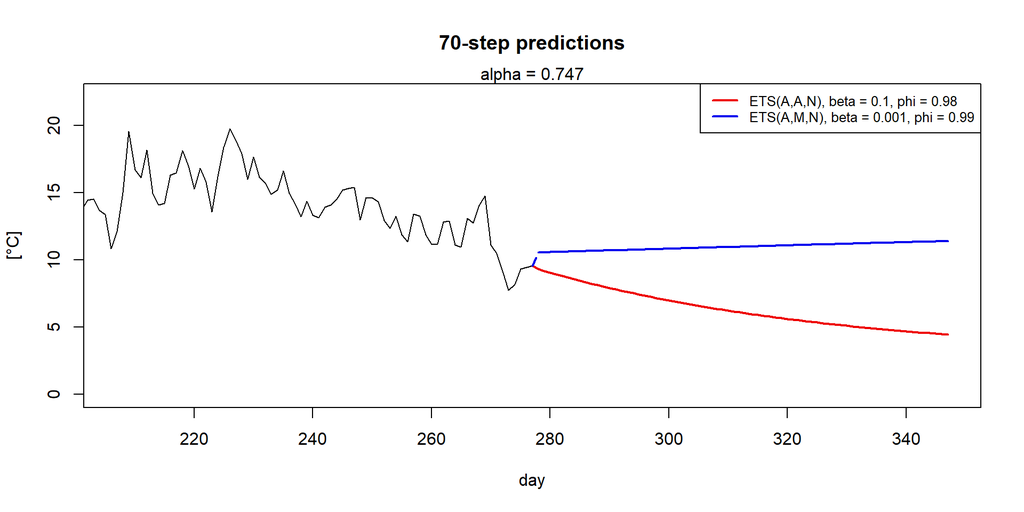

The multiplicative version of this method seems to work for $\beta \ll \phi$, as the cumulative sum in the exponent causes the predictions to diverge for trend values $b_n > 1$.

When $\beta = 0$ the ETS model becomes a simple level smoothing model, leading to a constant long-term prediction. Increasing $\beta$ to values slightly above zero leads to a prediction with an overdamped trend. The trend becomes more apparent as we increase $\beta$ up to a point where it is no longer overdamped by $\phi$, as we can see in the plot below:

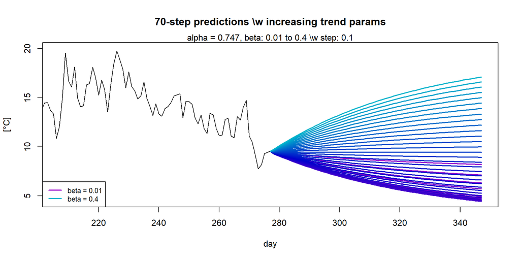

Naturally, we want to choose $\beta$ such that the damped trend predictions describe the evaluation part most accurately.

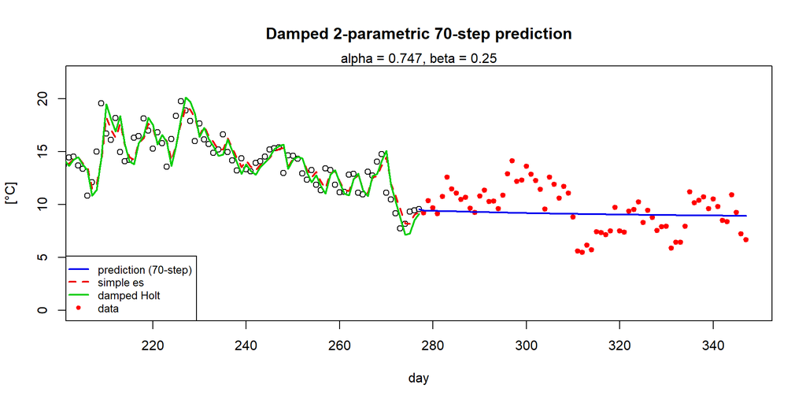

### 7.4 ETS Model Comparison (Conclusion)

Since the data contains no apparent or significant trend, nor seasonality, we only examined simple ETS models. The first two results of a $BIC$ search are:

```
##     alpha sigma^2      AIC      BIC
## 747 0.747 2.90929 1857.664 1864.912
## 748 0.748 2.90929 1857.664 1864.912
```

```
## [1] 3.547605
```

and $BIC$:

```
## [1] 1928.09
```

We can compare the predictive abilities of models $ETS(A,N,N)$ and $ETS(A,A_d,N)$ with the DM test:

```
##
##  Diebold-Mariano Test
##
## data:  e_1e_2
## DM = -2.1556, Forecast horizon = 1, Loss function power = 2,
## p-value = 0.03461
## alternative hypothesis: two.sided
```

which suggests significantly better predictive properties of the simple $ETS(A,N,N)$ with $\alpha = 0.747$. The RMSE’s of the above models are:

```
## [1] 0.220368
```

and

```
## [1] 0.2056627
```

## Discussion

We have evaluated daily averaged temperature measurements taken over year 2015 on a wind farm with the basic approaches of time series analysis, namely: decomposition, modeling residuals as a stationary (ARMA) process and introduced integrated processes and exponential smoothing (ETS) as well.

Technique (a) yields the best results since it clearly addresses the seasonality of the data and then models the residuals as stationary ARMA processes:

```
##               model RMSE(1)      BIC
## 13        ARMA(1,0) 1.29222 1051.252
## 14        ARMA(1,2) 1.28199 1056.256
## 15        ARMA(1,1) 1.29477 1056.484
## 16        ARMA(2,1) 1.31172 1057.184
## 17        ARMA(1,3) 1.28197 1058.852
## 7  ARFIMA(0,0.49,1) 1.28419 1069.949
```

Yet compared with ETS models in (c), more precisely $ETS(A,N,N),\alpha=0.747$ with $RMSE(1) = 0.220368$ they do not posses significantly better predictive abilites than the best ARMA model, as shown through the DM-test:

```
##
##  Diebold-Mariano Test
##
## data:  e_1e_arma
## DM = 0.63926, Forecast horizon = 1, Loss function power = 2,
## p-value = 0.5248
## alternative hypothesis: two.sided
```

Approach (b) was only used as an exercise with no significant difference in predictive abilities (merely between two specific ARIMA models). The residuals $\varepsilon_t$ in approach (a) can be considered random even though Diagnostic tests such as the Jarque-Bera test rejected their normality. The same can be applied on the residuals of approach (c):

```r
tseries::jarque.bera.test(e_1) # normality of ETS resids
```

```
##
##  Jarque Bera Test
##
## data:  e_1
## X-squared = 0.80637, df = 2, p-value = 0.6682
```

```r
randtests::runs.test(e_1) # randomness of ETS resids
```

```
##
##  Runs Test
##
## data:  e_1
## statistic = -0.2408, runs = 35, n1 = 35, n2 = 35, n = 70, p-value
## = 0.8097
## alternative hypothesis: nonrandomness
```

```r
randtests::runs.test(e_arma) # randomness of ARMA resids
```

```
##
##  Runs Test
##
## data:  e_arma
## statistic = -1.204, runs = 31, n1 = 35, n2 = 35, n = 70, p-value =
## 0.2286
## alternative hypothesis: nonrandomness
```